# Boris Bikes - A Data-Powered Journey

## By Brett Moreton

## Dataset Overview

I decided to use a dataset produced by Transport for London (TfL) which details the use of the city's biycle hire scheme, which are currently branded as Santander Cycles, after the bank Santander who currently sponsor them. To me and many other Londoners of my generation, they will always be Boris Bikes, and I will refer to them as such henceforce.

Due to computing restrictions I am analysing data from a 4 week period between 3rd July 2019 to 30th July 2019. In this period the dataset holds over 1 million journey records. For the analysis on COVID-19 and the Lockdown I bring in limited data for the full year of 2019 and up until 26th May 2020.

## Investigation Overview

For my presentation I will show how and when Boris Bikes are used. First we will look at the duration of a typical journey, and then see what days and what time of day these journey's happen. We'll look where journey's are starting and ending, and see that North London has significantly fewer docking stations when compared to East, South and West London. But who has the highest utilisation rates? Let's find out.

I will also show how Boris Bike usage changed during the COVID-19 Lockdown.

## Journey Durations

The majority of journeys made on Boris Bike's are short in nature, with 96% being less than 60 minutes duration from start to finish, and the average journey length was 21 minutes. Bike hires exceeding 24 hours were considered erroneous and removed from the dataset, as were journey's less than 1 minute in length.

The journey durations are likely to be a result of one of the main usecases (commuters joining up their commute with short bike journeys from their home to stations, or stations to offices, for example), and as a result of TfL's pricing structure, which can be summarised as follows:

> Hiring a Santander Cycle costs £2 for unlimited journeys up to 30 minutes, within a 24 hour period. For journeys longer than 30 minutes, you pay £2 for each additional 30 minutes. You must return the cycle within 24 hours or you may be charged.

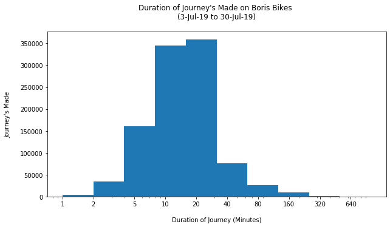

```python
plt.figure(figsize = [10, 5])
bin_edges = 10**np.arange(0, dur_log.max()+0.1, 0.3);
plt.hist(dur, bins=bin_edges);
plt.xscale('log')
tick_locs = [1, 2, 5, 10, 20, 40, 80, 160, 320, 640]
plt.xticks(tick_locs, tick_locs);
plt.xlabel('\nDuration of Journey (Minutes)'); plt.ylabel("Journey's Made\n");
plt.title("Duration of Journey's Made on Boris Bikes \n(3-Jul-19 to 30-Jul-19)\n");
```

## Journey's Made on Boris Bikes by Day

Wednesday's are the most popular day for Boris Bike journey's, with over 168,100 journey's made in the 4 week period. Most weekdays are similarly busy, with a drop off on Friday's, when more people tend to work from home or go out after work.

Weekends are quieter but still surprisingly busy - I expect that tourists will be making up the large majority of journeys on the weekends, and there were still almost 240,000 journey's made over the 8 Saturday's and Sunday's in the data sample. London is popular!

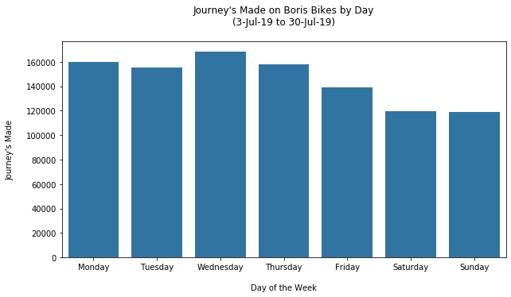

```python
# Replot
plt.figure(figsize = [10, 5])
base_color = sb.color_palette()[0]
sb.countplot(data = df, x = 'end_day', color=base_color);
plt.xlabel("\nDay of the Week"); plt.ylabel("Journey's Made\n");
plt.title("Journey's Made on Boris Bikes by Day\n(3-Jul-19 to 30-Jul-19)\n");
```

## Journey's Made on Boris Bikes by Time of Day

It turns out that on weekdays, the evening (4-8pm) and the morning (8-12noon) are the two most popular times. Most likely these are the times that London's hardworking busy-bees are getting themselves to and from the office, as fast as possible.

At the weekends this dynamic changes and the midday (12-4pm) is most popular for journeys, with the early evening (4-8pm) proving to be popular too.

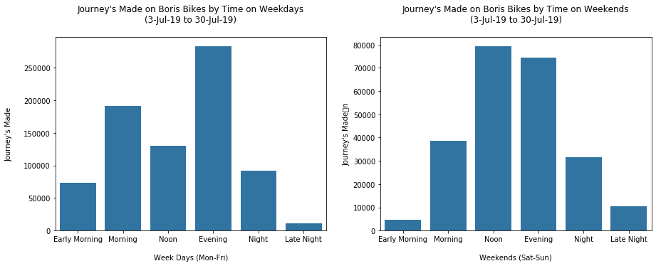

```python
plt.figure(figsize = [15, 5])
base_color = sb.color_palette()[0]

plt.subplot(1, 2, 1);
sb.countplot(data = df_weekday, x = 'start_time', color=base_color);
plt.xlabel("\nWeek Days (Mon-Fri)"); plt.ylabel("Journey's Made\n");
plt.title("Journey's Made on Boris Bikes by Time on Weekdays\n(3-Jul-19 to 30-Jul-19)\n");

plt.subplot(1, 2, 2);
sb.countplot(data = df_weekend, x = 'start_time', color=base_color);
plt.xlabel("\nWeekends (Sat-Sun)"); plt.ylabel("Journey's Made\an");
plt.title("Journey's Made on Boris Bikes by Time on Weekends\n(3-Jul-19 to 30-Jul-19)\n");
```

## Journeys Start and End Location

Here we can see the over half of the journey's started in Central London, with most of those ending in Central London too. Lot's of these journey's are likely to be commuters travelling 'the last mile' from mainline rail stations or tube stations to their offices, while at weekends tourists will be exploring Central London.

We can also clearly see the journey's starting in North, East, South and West London going in to Central London. These are likely to be commuters in Zone's 2 and 3 using Boris Bikes as a form of transport. These flows reverse as they make their journey's back home after work.

Please note, I have had to paste an image of the plotly Sankey Diagram as the plot is not rendering in the slideshow.

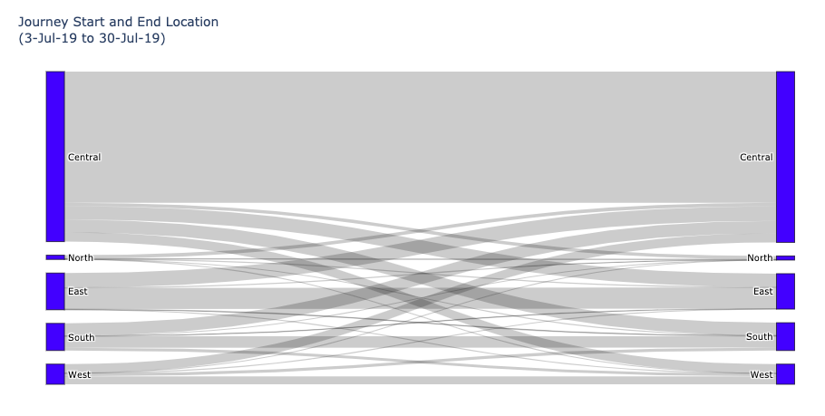

## Outside of Central London

North London has comparatively fewer docking stations to it's compass cousins, with only 17 versus East London's 135.

The plot on the right shows that the average number of journey's from each docking station was roughly the same, in the range of 35-38 journeys per docking station per day. Interestingly, the docking stations in North London had a higher minimum average usage per day, of 17 journeys. The closest competitor to this was West London's docking stations with an average minimum of just 6 journeys per day.

This shows that, although North London has fewer docking stations, they are very well utilised, and I suspect they need to be restocked quite quickly throughout peak commuter hours. North London could be in line for an expansion in it's docking stations in the near future - properties close to new docking stations could be seeing an increase in value!

The chart on the right also shows that East and South London have some very popular docking stations, with over 150 journey’s started from them each day. They also have some very quiet ones, which were perhaps not well located in the first place.

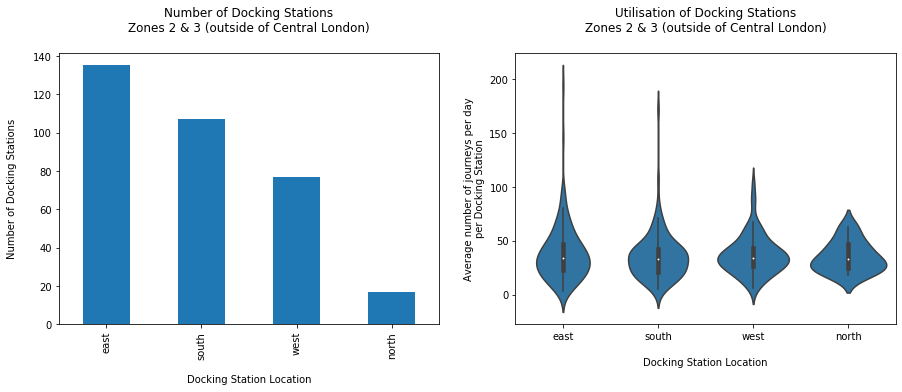

```python
# Note that cells below need to be run before this one, to create scatter_df

plt.figure(figsize = [15, 5])
base_color = sb.color_palette()[0]

plt.subplot(1, 2, 1);
z2station_counts.plot.bar();
plt.xlabel("\nDocking Station Location"); plt.ylabel("Number of Docking Stations\n");
plt.title("Number of Docking Stations\nZones 2 & 3 (outside of Central London)\n");

plt.subplot(1, 2, 2);
sb.violinplot(data = scatter_df, x = 'compass', y = 'journeys', color = base_color, order = ["east", "south", "west", "north"]);
plt.ylabel("Average number of journeys per day\nper Docking Station"); plt.xlabel("\nDocking Station Location")
plt.title("Utilisation of Docking Stations\nZones 2 & 3 (outside of Central London)\n");
```

## COVID-19 and Lockdown in London

The UK and London went into official "lockdown" on 23rd March 2020, with all citizens required to stay at home unless they had Key Worker status, or could not do their jobs from home. The number of commuters in to London plummeted, and tourists were either already gone or obliged to stay in their hotels/accommodation until they left the UK.

We can see significant decreases in Boris Bike journeys made as the lockdown comes in to force, and for the week ending 31st March there were just 68,184 journeys made across London. At the same time in 2019 there was around 200,000 journey's made.

Interestingly the number of journeys begins to increase in April, however not to "normal" April levels as per 2019. Perhaps this was down to people using Boris Bikes to commute to work, instead of trains, tubes and buses. Meanwhile significant numbers of London's residents were locked down.

The UK's Lockdown measures were eased on 11th May, and from this date we can see the number of journeys taken on Boris Bikes spikes significantly. In the week ending 26th May a high of 312,668 journeys was made in one week.

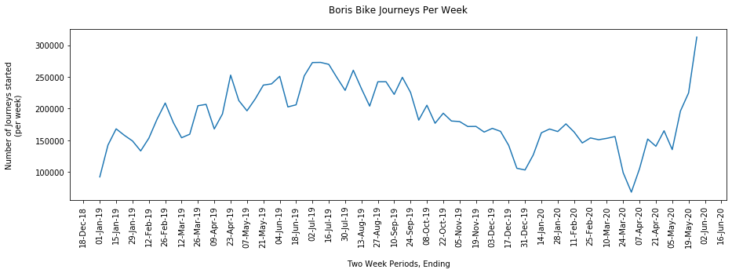

```python
from matplotlib.dates import DateFormatter
import matplotlib.dates as mdates

# Create figure and plot space
fig, ax = plt.subplots(figsize=(15, 4))

# Add plot
sb.lineplot(data=df7, x="week_ending", y="counts");

# Set title and labels for axes
ax.set(xlabel="\nTwo Week Periods, Ending",
       ylabel="Number of Journeys started\n(per week)\n",
       title="Boris Bike Journeys Per Week\n");

# Define the date format
date_form = DateFormatter("%d-%b-%y")
ax.xaxis.set_major_formatter(date_form)

# Ensure a major tick for each week using (interval=1)
ax.xaxis.set_major_locator(mdates.WeekdayLocator(interval=2))
plt.xticks(rotation=90);

plt.show()
```